# Exercícios Aprendizado Supervisionado parte 3

### **Autor:** Glauco Lauria Marques Filho

# Resumo

#### Este arquivo contém a resolução dos exercícios da Aula 6 do curso CEDS-808: Aprendizado de Máquina.

# Sumário

- Início
- Resumo
- Sumário
- Importação de Requisitos
1. Dataset Forest Fires
- 1.a Pre-processamento dos Dados
- 1.b Testes com Modelos
2. Diferenças entre Regressão e Predição de séries temporais

# Importação de Requisitos

```python
from ucimlrepo import fetch_ucirepo # Biblioteca que possui os dados da base Breast Cancer Winconsin
import matplotlib.pyplot as plt
import seaborn as sns
from sklearn.preprocessing import MinMaxScaler
import pandas as pd
from sklearn.model_selection import cross_val_score, KFold
from sklearn.neighbors import KNeighborsRegressor
from sklearn.tree import DecisionTreeRegressor
from sklearn.svm import SVR, NuSVR
from sklearn.neural_network import MLPRegressor
from sklearn.model_selection import train_test_split
import numpy as np
```

# 1. Dataset Forest Fires

Utilizando o dataset Forest Fires para o exercício. Importando o dataset da biblioteca, e carregando dataframes de Features e Target.

```python
# Importando o dataset Forest Fires
ffire = fetch_ucirepo(id=162)
# Definindo dataframe de Features e target
X = ffire.data.features
y = ffire.data.targets
```

Pritando um pouco dos dataframes para uma primeira exploração da base de dados.

```python
X.head()
```

|  | X | Y | month | day | FFMC | DMC | DC | ISI | temp | RH | wind | rain |
| --- | --- | --- | --- | --- | --- | --- | --- | --- | --- | --- | --- | --- |
| 0 | 7 | 5 | mar | fri | 86.2 | 26.2 | 94.3 | 5.1 | 8.2 | 51 | 6.7 | 0.0 |
| 1 | 7 | 4 | oct | tue | 90.6 | 35.4 | 669.1 | 6.7 | 18.0 | 33 | 0.9 | 0.0 |
| 2 | 7 | 4 | oct | sat | 90.6 | 43.7 | 686.9 | 6.7 | 14.6 | 33 | 1.3 | 0.0 |
| 3 | 8 | 6 | mar | fri | 91.7 | 33.3 | 77.5 | 9.0 | 8.3 | 97 | 4.0 | 0.2 |
| 4 | 8 | 6 | mar | sun | 89.3 | 51.3 | 102.2 | 9.6 | 11.4 | 99 | 1.8 | 0.0 |

```python
y.tail()
```

|  | area |
| --- | --- |
| 512 | 6.44 |
| 513 | 54.29 |
| 514 | 11.16 |
| 515 | 0.00 |
| 516 | 0.00 |

De acordo com a referência, este conjunto de dados apresenta as seguintes características:

- **X** corresponde à coordenada X.
- **Y** indica a coordenada Y.
- **month** representa o mês da ocorrência do incêndio.
- **day** refere-se ao dia da semana em que o incêndio ocorreu.
- **FFMC** (corrigido de FMC) é um índice que mede a umidade do combustível fino.
- **DMC** é um índice que avalia a umidade do combustível mais pesado ou compacto.
- **DC** é um índice que determina o nível de secura do solo.
- **ISI** é um índice relacionado à velocidade de propagação do incêndio.
- **temp** indica a temperatura em graus Celsius.
- **RH** refere-se à umidade relativa, expressa em percentual.
- **wind** mede a velocidade do vento.
- **rain** quantifica a precipitação em milímetros.
- **area** mensura a extensão da área afetada pelo incêndio, em hectares.

# 1.a Pre-processamento dos Dados

Faremos agora um pre-processamento dos dados para utilizar em futuras analises.

Inicialmente vamos verificar os dados ausentes.

```python
null_values = X.isnull().sum()
null_values
```

```
X        0
Y        0
month    0
day      0
FFMC     0
DMC      0
DC       0
ISI      0
temp     0
RH       0
wind     0
rain     0
dtype: int64
```

Nao possuimos itens ausentes. Vamos dar uma olhada na distribuicao dos dados que representa mais medicoes (aqueles nao categoricos).

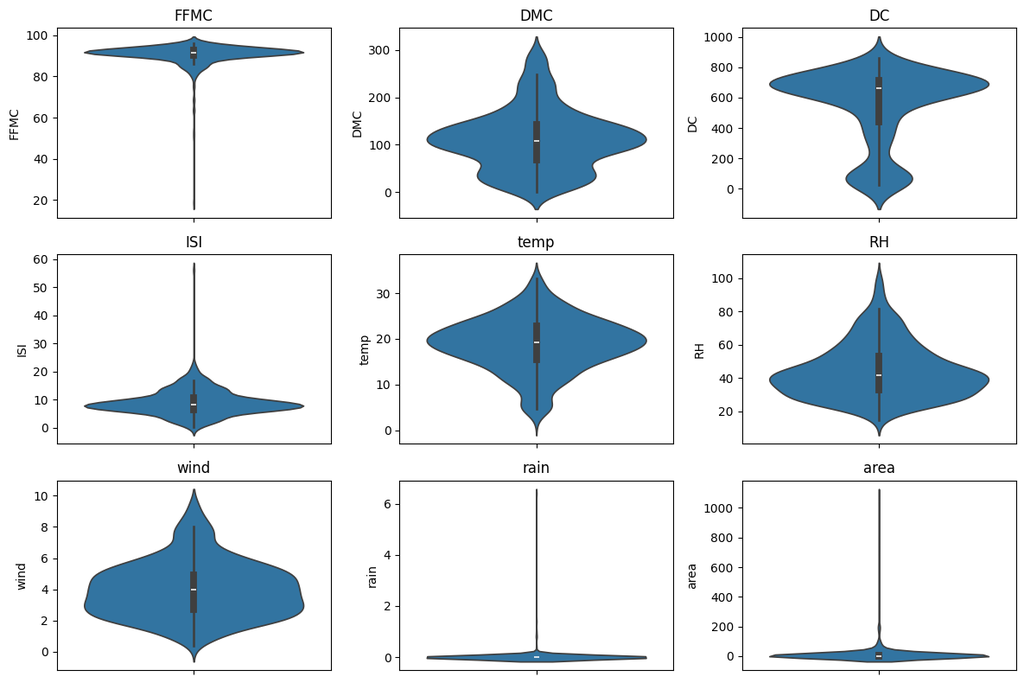

```python
X_plot = X[['FFMC', 'DMC', 'DC', 'ISI', 'temp', 'RH', 'wind', 'rain']]
X_plot["area"] = y


plt.figure(figsize=(12, 8))
for i, column in enumerate(X_plot.columns, 1):
    plt.subplot(3, 3, i)
    sns.violinplot(y=X_plot[column])
    plt.title(column)

plt.tight_layout()
plt.show()
```

A media de rain dara zero, logo vamos remover essa feature.

```python
X["area"] = y
del X["rain"]
verificar_outiliers = ['FFMC', 'DMC', 'DC', 'ISI', 'temp', 'RH', 'wind', 'area'] # 'rain'
antes = len(X)
for coluna in verificar_outiliers:
    Q1 = X[coluna].quantile(0.25)
    Q3 = X[coluna].quantile(0.75)
    IQR = Q3 - Q1

    limite_inferior = Q1 - 2.5 * IQR
    limite_superior = Q3 + 2.5 * IQR

    X = X[(X[coluna] >= limite_inferior) & (X[coluna] <= limite_superior)]

    # media = X[(X[coluna] >= limite_inferior) & (X[coluna] <= limite_superior)][coluna].mean()

    # X.loc[X[coluna] < limite_inferior, coluna] = media
    # X.loc[X[coluna] > limite_superior, coluna] = media

removidos = len(X) - antes
print(f"{removidos} linhas removidas")
```

```
-81 linhas removidas
```

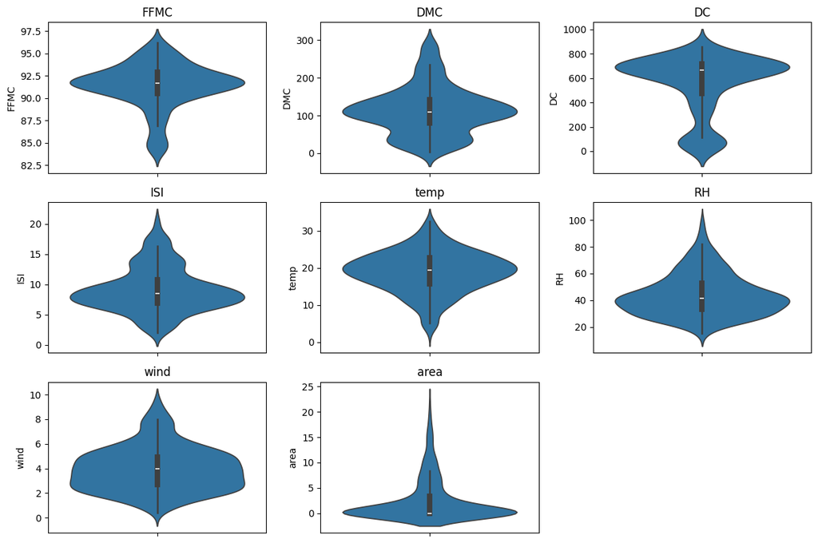

```python
X_plot = X[['FFMC', 'DMC', 'DC', 'ISI', 'temp', 'RH', 'wind', 'area']]
plt.figure(figsize=(12, 8))
for i, column in enumerate(X_plot.columns, 1):
    plt.subplot(3, 3, i)
    sns.violinplot(y=X_plot[column])
    plt.title(column)

plt.tight_layout()
plt.show()

y = X["area"]
del X["area"]
```

Podemos perceber que a distribuicao para as medidas ficaram muito mais comportadas.

O Valor day tambem sera desconsiderado pelo autor pois aparenta ser uma variavel que nao carrega muita informacao util. Apos alguns testes o autor percebeu que month tambem nao afetava muito o modelo, tambem sera removida.

```python
del X["day"]
del X["month"]
# mes_para_numero = {
#     'jun': 6,
#     'jul': 7,
#     'aug': 8,
#     'sep': 9,
#     'oct': 10,
# }
# X['month'] = X['month'].map(mes_para_numero)
# X = pd.get_dummies(X, columns=['month'],dtype=int)
# X
```

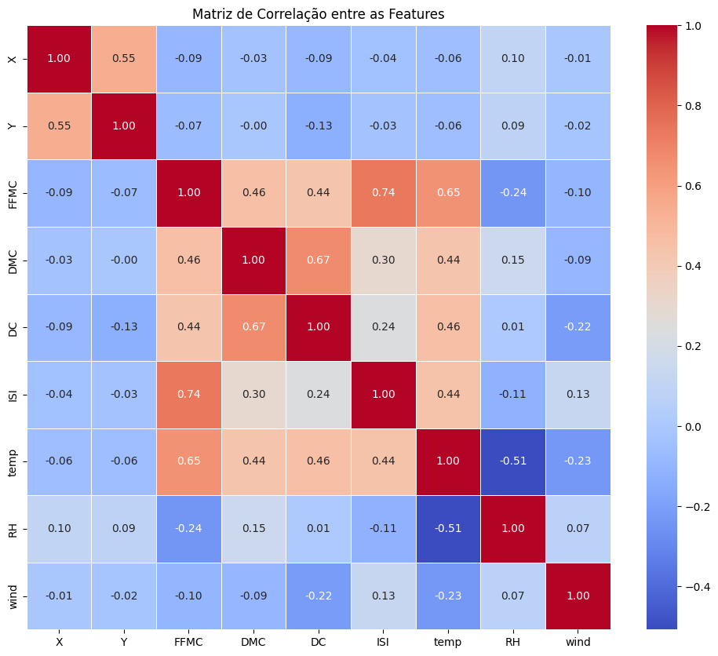

```python
correlation_matrix = X.corr()
plt.figure(figsize=(12, 10))
sns.heatmap(correlation_matrix, annot=True, cmap='coolwarm', fmt=".2f", linewidths=0.5)
plt.title('Matriz de Correlação entre as Features')
plt.show()
```

Passamos agora para uma normalizacao.

```python
scaler = MinMaxScaler()
X = scaler.fit_transform(X)
scaler = MinMaxScaler()
y = y.values.reshape(-1, 1)
y = scaler.fit_transform(y).flatten()
```

# 1.b Testes com Modelos

Com os dados pre-processados passaremos agora em alguns modelos com diferentes parametros.

```python
cv = KFold(n_splits=5, shuffle=True, random_state=42)

modelos_str = []
modelos = []
for i in range(3,12,2):
    modelos_str.append(f"KNN n = {i}")
    modelos.append(KNeighborsRegressor(n_neighbors=i))
for i in range(3,12,2):
    modelos_str.append(f"DT max_depth = {i}")
    modelos.append(DecisionTreeRegressor(max_depth=i))
for i in ['linear', 'poly', 'rbf', 'sigmoid']:
    modelos_str.append(f"SVR kernel = {i}")
    modelos.append(SVR(kernel=i))
for i in ['linear', 'poly', 'rbf', 'sigmoid']:
    for j in range(1,9,2):
        j = j / 10
        modelos_str.append(f"NuSVR kernel = {i}, nu = {j:.1f}")
        modelos.append(NuSVR(kernel=i, nu=j))
hidden_layer_sizes = [(100,), (50,), (50, 20)]
activations = ['relu', 'tanh']
solvers = ['adam', 'sgd']
max_iters = [500, 1000]
for hidden_layer_size in hidden_layer_sizes:
    for activation in activations:
        for solver in solvers:
            for max_iter in max_iters:
                f"MLP hidden_layer_sizes = {hidden_layer_size}, activation = {activation}, solver = {solver}, max_iter = {max_iter}"
                modelos.append(MLPRegressor(hidden_layer_sizes=hidden_layer_size, activation=activation, solver=solver, max_iter=max_iter, random_state=42))


for modelo, name in zip(modelos,modelos_str):
    mae = cross_val_score(modelo, X, y, scoring='neg_mean_absolute_error', cv=cv)
    mse = cross_val_score(modelo, X, y, scoring="neg_mean_squared_error", cv=cv)
    r2 = cross_val_score(modelo, X, y, scoring="r2", cv=cv)

    print(f"{modelo.__class__.__name__}:")
    print(name)
    print(f"  MAE médio: {-np.mean(mae):.4f} (+- {np.std(mae):.4f})")
    print(f"  MSE médio: {np.mean(mse):.4f} (+- {np.std(mse):.4f})")
    print(f"  R2 médio: {np.mean(r2):.4f} (+- {np.std(r2):.4f})\n")
```

```
KNeighborsRegressor:
KNN n = 3
  MAE médio: 0.1526 (+- 0.0090)
  MSE médio: -0.0458 (+- 0.0051)
  R2 médio: -0.2741 (+- 0.1850)

KNeighborsRegressor:
KNN n = 5
  MAE médio: 0.1495 (+- 0.0127)
  MSE médio: -0.0426 (+- 0.0057)
  R2 médio: -0.1767 (+- 0.1139)

KNeighborsRegressor:
KNN n = 7
  MAE médio: 0.1475 (+- 0.0118)
  MSE médio: -0.0408 (+- 0.0061)
  R2 médio: -0.1233 (+- 0.1108)

KNeighborsRegressor:
KNN n = 9
  MAE médio: 0.1474 (+- 0.0110)
  MSE médio: -0.0403 (+- 0.0064)
  R2 médio: -0.1070 (+- 0.0926)

KNeighborsRegressor:
KNN n = 11
  MAE médio: 0.1460 (+- 0.0093)
  MSE médio: -0.0397 (+- 0.0059)
  R2 médio: -0.0900 (+- 0.0624)

DecisionTreeRegressor:
DT max_depth = 3
  MAE médio: 0.1369 (+- 0.0079)
  MSE médio: -0.0369 (+- 0.0082)
  R2 médio: 0.0241 (+- 0.1190)

DecisionTreeRegressor:
DT max_depth = 5
  MAE médio: 0.1487 (+- 0.0113)
  MSE médio: -0.0459 (+- 0.0108)
```

[output cut: 124 more lines]

```
  MAE médio: 1.4268 (+- 0.0375)
  MSE médio: -3.6758 (+- 0.4148)
  R2 médio: -103.7644 (+- 29.6012)

NuSVR:
NuSVR kernel = sigmoid, nu = 0.5
  MAE médio: 1.7346 (+- 0.0620)
  MSE médio: -6.8534 (+- 1.1081)
  R2 médio: -193.9635 (+- 59.6847)

NuSVR:
NuSVR kernel = sigmoid, nu = 0.7
  MAE médio: 1.9431 (+- 0.1025)
  MSE médio: -9.8024 (+- 1.8831)
  R2 médio: -278.2139 (+- 92.0056)
```

```python
# SVR kernel = linear
#   MAE médio: 0.1365 (+- 0.0097)
#   MSE médio: -0.0371 (+- 0.0062)
#   R2 médio: -0.0125 (+- 0.0136)

modelo = SVR(kernel="linear")
X_train, X_test, y_train, y_test = train_test_split(X, y, test_size=0.2, random_state=42)
print(f"{modelo.__class__.__name__}:")
print("SVR kernel = linear")

modelo.fit(X_train, y_train)
y_pred = modelo.predict(X_test)
diferencas = np.abs(y_test - y_pred)
df_resultados = pd.DataFrame({
"Valor Real": y_test,
"Valor Predito": y_pred,
"Diferença": diferencas
})
df_resultados = df_resultados.sort_values("Diferença",ascending=True)
with pd.option_context('display.max_rows', None, 'display.max_columns', None):
    print(df_resultados)
```

```
SVR:
SVR kernel = linear
    Valor Real  Valor Predito  Diferença
63    0.096686       0.099931   0.003244
46    0.091239       0.100174   0.008935
14    0.088062       0.099615   0.011554
52    0.088062       0.099834   0.011772
44    0.086246       0.099674   0.013428
19    0.079437       0.099685   0.020248
47    0.078075       0.099990   0.021914
71    0.124376       0.100079   0.024297
73    0.124830       0.100470   0.024359
28    0.125738       0.100017   0.025721
5     0.066727       0.099999   0.033272
3     0.057195       0.100025   0.042830
```

[output cut: 76 more lines]

Mesmo o melhor modelo ainda possui grandes erros de predicao, para futuros trabalhos seria melhor fazer uma combinacao eliminando algumas features ate encontrar as features mais relevantes, para tentar chegar a uma acuracia maior.

# 2. Diferenças entre Regressão e Predição de séries temporais

Primeiramente, a regressão é utilizar para tentar explicar como variáveis independentes afetam uma variável dependente, um exemplo seria tentar descobrir o impacto de diferentes fatores, como horas de estudo, horas de sono, alimetacao afetam as notas de um aluno, sem considerar o aspecto temporal em que esses fatores ocorrem.

No caso da previsão de séries temporais, essa foca em analisar dados que são gerados ao longo do tempo para prever futuras ocorrências com base em tendências passadas. Por exemplo, você tem registrado como seus gastos evoluem durante um ano mensalmente, voce pode tentar prever um gasto futuro considerando os padrões observados anteriormente.

Em resumo, previsão de séries temporais é ideal para lidar com dados sequenciais, levando em conta fatores como tendências e sazonalidades. Por outro lado a regressão busca entender relações entre variáveis.